# weekEight

# How to write in Markdown

## Basics

Markdown does not control the typography of your document like Microsoft Word and similar software do. How a document looks can still be controlled (e.g., using css file - don’t worry about this), but that part is outsourced, and not Markdown’s problem. Markdown controls everything that deals with the structure of a document, like headers, lists, bold and italic text, links, images, block quotes.

### Headers

The headers’ hierarchy (i.e., title, section, subsection, etc.) can be controlled in a couple of ways. I will offer here my personal favourite: the number of “#” at the beginning of a line determines the hierarchy of the header. Typically, # comes before a title, ## is for sections, ### for subsections, and so on. If a line starts without any “#” characters, it’s the body of the document. You can read the linked resources for more ways to have headers in a document, and can use the one you prefer.

### Body of a document

The body of a document can just be typed in.

In Markdown, a new paragraph is created by skipping a line, while manual line breaks by ending a line with two or more spaces:

Roses are red,  
Violets are blue.

Unlike Word, it is not enough to simply press return.

If you need to type words in *italic* or **bold**, you use one or two "*" around the words or the sentences you want in italic or in bold.

You can also have block quotes, using the “>” character at the beginning of a new line. This is useful for quotations, like in:

> It’s always better to give than to receive.

### Lists

Lists can be started with a "*" or a “-”:

- first item
  - first subitem
  - second subitem
- second item
  - first subitem
  - Second subitem
  - third subitem

List can also be numbered lists:

1. first numbered item
   1. first subitem
   2. second subitem
2. second numbered item

#### LaTeX equations

Writing equations is essential in any statistical report and that’s one of the reasons why academics use LaTeX. This should work better as part of the LaTeX discussion. Stay tune!

#### Tables

Tables could be generated following the spirit of Markdown, i.e. in a way that is easy to read from the source file like in the following:

| First Header | Second Header |
| --- | --- |
| Content Cell | Content Cell |
| Content Cell | Content Cell |

The idea is similar to `tribble()` which is useful for small tables of data where readability is important. This is difficult to maintain though (try adding a column!). Instead, we will use R Markdown for that, creating tables out of data frame/tibble. We will circle back to this point in the coming weeks.

#### Footnotes

Footnotes allow you to add notes and references without cluttering the body of the document. When you create a footnote, a superscript number with a link appears where you added the footnote reference. Readers can click the link to jump to the content of the footnote at the bottom of the page.

Here’s a simple footnote,[^1] and here’s a longer one.[^2]

#### Superscripts & Subscripts

superscript<sup>2</sup>  
or  
superscript<sup>2</sup>  
or superscript$^2$

subcript<sub>2</sub>  
or subcript$_2$

*Again, this is only relevant for the standard text. In equations, we can use the better LaTeX syntax.*

#### Strikethrough text

This is actually useful when you want to delete a part of your document that could be useless in the future. strikethrough

Restoring it is a matter of seconds (just delete the “~” characters).

```r
set.seed(10)
library(tidyverse)
# Create data sampling from std norm distribution
n <- 100
n_sim <- 1000
x0 <- rnorm(n = n * n_sim, mean = 0, sd = 1)
x <- as_tibble(matrix(x0, nrow = n, ncol = n_sim),
  .name_repair = "universal"
)
```

[output not shown]

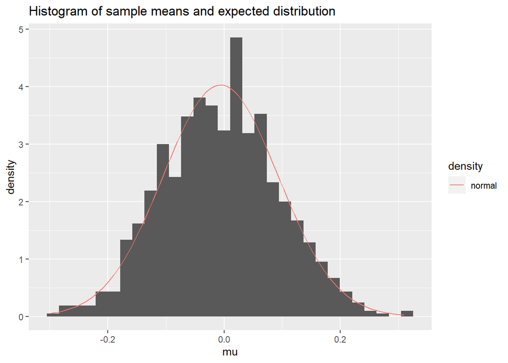

```r
# Compute 1000 (n_sim) sample means
mu <- x %>%
  map_dbl(mean)
# Estimate the main parameters (mean and standard deviation) of the distribution of the sample mean
mu_mu <- mean(mu)
sd_mu <- sd(mu)
# Plot the histogram to estimate the distribution of the sample mean and the expected density distribution
ggplot(tibble(mu = mu), aes(x = mu)) +
  geom_histogram(aes(y = ..density..)) +
  ggtitle("Histogram of sample means and expected distribution") +
  xlab("mu") +
  ylab("density") +
  scale_colour_discrete(name = "density") +
  geom_function(aes(colour = "normal"),
    fun = dnorm,
    args = list(mean = mu_mu, sd = sd_mu)
  )
```

[^1]: This is the first footnote.
[^2]: Here’s one with multiple paragraphs and code.

    Indent paragraphs to include them in the footnote.

    `{ my code }`

    Add as many paragraphs as you like.